# AN588-Week3

Jess Martin

2023-09-23

(Module 6: Exploratory Data Analysis)

```r
library(curl)
f <- curl("https://raw.githubusercontent.com/fuzzyatelin/fuzzyatelin.github.io/master/AN588_Fall23/Country-Data-2016.csv")
d <- read.csv(f, header = TRUE, sep = ",", stringsAsFactors = FALSE)
head(d)
```

```
##          country population    area                      govt_form birthrate
## 1    Afghanistan   32564342  652230               islamic republic      38.6
## 2        Albania    3029278   28748                       republic      12.9
## 3        Algeria   39542166 2381741                       republic      23.7
## 4 American Samoa      54343     199 territory of the United States      22.9
## 5        Andorra      85580     468        constitutional monarchy       8.1
## 6         Angola   19625353 1246700                       republic      38.8
##   deathrate life_expect mammals birds reptiles amphibians fishes mollucs
## 1      13.9        50.9      11    17        1          1      5       0
## 2       6.6        78.1       3    10        4          2     44      49
## 3       4.3        76.6      14    14        8          3     40      10
## 4       4.8        75.1       1     8        6          0     12       5
## 5       7.0        82.7       2     2        1          0      0       3
## 6      11.5        55.6      17    26        5          0     51       5
##   other_inverts plants fungi_protists
## 1             2      5              0
## 2            13      0              0
## 3            26     18              0
## 4            59      1              0
## 5             4      0              0
## 6             4     34              0
```

```r
summary(d)
```

```
##    country            population             area           govt_form
##  Length:248         Min.   :3.000e+01   Min.   :       0   Length:248
##  Class :character   1st Qu.:2.991e+05   1st Qu.:    1769   Class :character
##  Mode  :character   Median :4.912e+06   Median :   69700   Mode  :character
##                     Mean   :2.999e+07   Mean   :  610952
##                     3rd Qu.:1.803e+07   3rd Qu.:  398754
##                     Max.   :1.367e+09   Max.   :17098242
##                     NA's   :6           NA's   :1
##    birthrate       deathrate      life_expect       mammals
##  Min.   : 0.00   Min.   : 0.00   Min.   :49.80   Min.   :  0.00
##  1st Qu.:11.40   1st Qu.: 5.65   1st Qu.:67.40   1st Qu.:  3.00
##  Median :16.40   Median : 7.40   Median :74.70   Median :  8.00
##  Mean   :18.95   Mean   : 7.61   Mean   :72.19   Mean   : 13.85
##  3rd Qu.:24.35   3rd Qu.: 9.40   3rd Qu.:78.40   3rd Qu.: 15.00
##  Max.   :45.50   Max.   :14.90   Max.   :89.50   Max.   :188.00
##  NA's   :17      NA's   :17      NA's   :19      NA's   :3
##      birds           reptiles         amphibians          fishes
##  Min.   :  0.00   Min.   :  0.000   Min.   :  0.000   Min.   :  0.00
##  1st Qu.:  6.00   1st Qu.:  2.000   1st Qu.:  0.000   1st Qu.: 11.00
##  Median : 12.00   Median :  5.000   Median :  0.000   Median : 25.00
##  Mean   : 17.82   Mean   :  8.331   Mean   :  9.849   Mean   : 32.84
##  3rd Qu.: 19.00   3rd Qu.:  8.000   3rd Qu.:  4.000   3rd Qu.: 43.00
##  Max.   :165.00   Max.   :139.000   Max.   :215.000   Max.   :249.00
##  NA's   :3        NA's   :3         NA's   :3         NA's   :3
##     mollucs       other_inverts        plants        fungi_protists
##  Min.   :  0.00   Min.   :  0.00   Min.   :   0.00   Min.   : 0.0000
##  1st Qu.:  0.00   1st Qu.:  3.00   1st Qu.:   2.00   1st Qu.: 0.0000
##  Median :  1.00   Median : 11.00   Median :  10.00   Median : 0.0000
##  Mean   :  9.62   Mean   : 32.57   Mean   :  60.78   Mean   : 0.6082
##  3rd Qu.:  6.00   3rd Qu.: 33.00   3rd Qu.:  44.00   3rd Qu.: 0.0000
##  Max.   :301.00   Max.   :340.00   Max.   :1856.00   Max.   :12.0000
##  NA's   :3        NA's   :3        NA's   :3         NA's   :3
```

```r
names(d)
```

```
##  [1] "country"        "population"     "area"           "govt_form"
##  [5] "birthrate"      "deathrate"      "life_expect"    "mammals"
##  [9] "birds"          "reptiles"       "amphibians"     "fishes"
## [13] "mollucs"        "other_inverts"  "plants"         "fungi_protists"
```

- What are the median area and population size of all countries in the dataset?
- HINT: There are a couple of ways to do this… try summary() and median() (for the latter, you’ll need to use the na.rm = TRUE argument)
- Create a new pop_density variable in your data frame which is population / area. What are the 10 most dense countries? The 10 least dense? HINT: check out the order() function

```r
summary (d)
```

```
##    country            population             area           govt_form
##  Length:248         Min.   :3.000e+01   Min.   :       0   Length:248
##  Class :character   1st Qu.:2.991e+05   1st Qu.:    1769   Class :character
##  Mode  :character   Median :4.912e+06   Median :   69700   Mode  :character
##                     Mean   :2.999e+07   Mean   :  610952
##                     3rd Qu.:1.803e+07   3rd Qu.:  398754
##                     Max.   :1.367e+09   Max.   :17098242
##                     NA's   :6           NA's   :1
##    birthrate       deathrate      life_expect       mammals
##  Min.   : 0.00   Min.   : 0.00   Min.   :49.80   Min.   :  0.00
##  1st Qu.:11.40   1st Qu.: 5.65   1st Qu.:67.40   1st Qu.:  3.00
##  Median :16.40   Median : 7.40   Median :74.70   Median :  8.00
##  Mean   :18.95   Mean   : 7.61   Mean   :72.19   Mean   : 13.85
##  3rd Qu.:24.35   3rd Qu.: 9.40   3rd Qu.:78.40   3rd Qu.: 15.00
##  Max.   :45.50   Max.   :14.90   Max.   :89.50   Max.   :188.00
##  NA's   :17      NA's   :17      NA's   :19      NA's   :3
##      birds           reptiles         amphibians          fishes
##  Min.   :  0.00   Min.   :  0.000   Min.   :  0.000   Min.   :  0.00
##  1st Qu.:  6.00   1st Qu.:  2.000   1st Qu.:  0.000   1st Qu.: 11.00
##  Median : 12.00   Median :  5.000   Median :  0.000   Median : 25.00
##  Mean   : 17.82   Mean   :  8.331   Mean   :  9.849   Mean   : 32.84
##  3rd Qu.: 19.00   3rd Qu.:  8.000   3rd Qu.:  4.000   3rd Qu.: 43.00
##  Max.   :165.00   Max.   :139.000   Max.   :215.000   Max.   :249.00
##  NA's   :3        NA's   :3         NA's   :3         NA's   :3
##     mollucs       other_inverts        plants        fungi_protists
##  Min.   :  0.00   Min.   :  0.00   Min.   :   0.00   Min.   : 0.0000
##  1st Qu.:  0.00   1st Qu.:  3.00   1st Qu.:   2.00   1st Qu.: 0.0000
##  Median :  1.00   Median : 11.00   Median :  10.00   Median : 0.0000
##  Mean   :  9.62   Mean   : 32.57   Mean   :  60.78   Mean   : 0.6082
##  3rd Qu.:  6.00   3rd Qu.: 33.00   3rd Qu.:  44.00   3rd Qu.: 0.0000
##  Max.   :301.00   Max.   :340.00   Max.   :1856.00   Max.   :12.0000
##  NA's   :3        NA's   :3        NA's   :3         NA's   :3
```

```r
median(d$area, na.rm = TRUE) #calculate the median area from dataset
```

```
## [1] 69700
```

```r
median(d$population, na.rm = TRUE) # calculate the median population from dataset
```

```
## [1] 4911766
```

```r
median_area <- median(d$area, na.rm = TRUE) #calculate the median area from dataset
median_population <- median (d$population, na.rm = TRUE) #calculate the median population from dataset
cat("Median Area:", median_area)
```

```
## Median Area: 69700
```

```r
cat("Median Population:", median_population)
```

```
## Median Population: 4911766
```

```r
d$density <- d$population/d$area
d <- d[order(-d$density), ]
d[1:10, ]
```

```
##                     country population   area
## 130                   Macau     592731   28.0
## 145                  Monaco      30535    2.0
## 97  Holy See (Vatican City)        842    0.1
## 199               Singapore    5674472  697.0
## 99                Hong Kong    7141106 1108.0
## 84                Gibraltar      29258    7.0
## 17                  Bahrain    1346613  760.0
## 135                Maldives     393253  298.0
## 137                   Malta     413965  316.0
## 24                  Bermuda      70196   54.0
##                                  govt_form birthrate deathrate life_expect
## 130 special administrative region of China       8.9       4.2        84.5
## 145                constitutional monarchy       6.7       9.2        89.5
## 97                                monarchy        NA        NA          NA
```

[output cut: 29 more lines]

```r
d <- d[order(d$density), ]
d[1:10, ]
```

```
##                                      country population    area
## 206 South Georgia and South Sandwich Islands         30    3903
## 86                                 Greenland      57733 2166086
## 70                          Falkland Islands       3361   12173
## 175                         Pitcairn Islands         48      47
## 146                                 Mongolia    2992908 1564116
## 245                           Western Sahara     570866  266000
## 76                             French Guiana     181000   83534
## 152                                  Namibia    2212307  824292
## 13                                 Australia   22751014 7741220
## 101                                  Iceland     331918  103000
##                        govt_form birthrate deathrate life_expect mammals birds
## 206   British overseas territory        NA        NA          NA       3     6
## 86  autonomous region of Denmark      14.5       8.5        72.1       9     3
## 70    British overseas territory        NA        NA          NA       4     9
```

[output cut: 29 more lines]

- Extract data from the 20 largest countries into a new variable. What are the median area and population size of these countries?
- Extract data from all countries beginning with the letters “A” through “F”. What are the mean area and population size of these countries?

```r
d <- d[order(-d$area), ] #order the data frame by area
size <- d[1:20, ] #extract data from the 20 largest countries
summary(size)
```

```
##    country            population             area           govt_form
##  Length:20          Min.   :5.773e+04   Min.   : 1564116   Length:20
##  Class :character   1st Qu.:2.525e+07   1st Qu.: 1949424   Class :character
##  Mode  :character   Median :4.343e+07   Median : 2553320   Mode  :character
##                     Mean   :2.136e+08   Mean   : 5264993
##                     3rd Qu.:1.733e+08   3rd Qu.: 8785398
##                     Max.   :1.367e+09   Max.   :17098242
##                     NA's   :1
##    birthrate       deathrate       life_expect       mammals
##  Min.   :10.30   Min.   : 3.300   Min.   :56.90   Min.   :  2.00
##  1st Qu.:13.50   1st Qu.: 6.150   1st Qu.:70.50   1st Qu.: 12.50
##  Median :18.00   Median : 7.300   Median :73.50   Median : 25.50
##  Mean   :17.98   Mean   : 7.147   Mean   :73.09   Mean   : 42.65
##  3rd Qu.:19.40   3rd Qu.: 8.200   3rd Qu.:76.45   3rd Qu.: 65.75
##  Max.   :34.90   Max.   :13.700   Max.   :82.20   Max.   :188.00
##  NA's   :1       NA's   :1        NA's   :1
##      birds           reptiles      amphibians         fishes
##  Min.   :  3.00   Min.   : 0.0   Min.   :  0.00   Min.   :  0.0
##  1st Qu.: 17.25   1st Qu.: 4.5   1st Qu.:  0.00   1st Qu.: 30.0
##  Median : 31.50   Median : 8.5   Median :  3.50   Median : 41.5
##  Mean   : 47.85   Mean   :20.5   Mean   : 29.90   Mean   : 77.9
##  3rd Qu.: 65.00   3rd Qu.:34.0   3rd Qu.: 38.75   3rd Qu.:121.8
##  Max.   :165.00   Max.   :97.0   Max.   :215.00   Max.   :249.0
##
##     mollucs       other_inverts        plants      fungi_protists
##  Min.   :  0.00   Min.   :  0.00   Min.   :  0.0   Min.   : 0.00
##  1st Qu.:  0.00   1st Qu.:  8.75   1st Qu.:  3.0   1st Qu.: 0.00
##  Median :  5.50   Median : 27.00   Median : 37.0   Median : 0.00
##  Mean   : 30.15   Mean   : 72.90   Mean   :158.8   Mean   : 1.10
##  3rd Qu.: 11.25   3rd Qu.: 69.50   3rd Qu.:391.5   3rd Qu.: 0.25
##  Max.   :301.00   Max.   :340.00   Max.   :574.0   Max.   :12.00
##
##     density
##  Min.   :  0.0267
##  1st Qu.:  5.1537
##  Median : 16.6022
##  Mean   : 50.0735
##  3rd Qu.: 41.7477
##  Max.   :380.7714
##  NA's   :1
```

```r
median(size$area, na.rm = TRUE) #calculate the median area
```

```
## [1] 2553321
```

```r
median(size$population, na.rm = TRUE) #calculate the median population
```

```
## [1] 43431886
```

```r
new <- d[grep("^[A-F]", d$country), ]
summary(new)
```

```
##    country            population             area           govt_form
##  Length:78          Min.   :5.960e+02   Min.   :      14   Length:78
##  Class :character   1st Qu.:2.991e+05   1st Qu.:    4066   Class :character
##  Mode  :character   Median :4.785e+06   Median :   51148   Mode  :character
##                     Mean   :3.507e+07   Mean   :  918248
##                     3rd Qu.:1.469e+07   3rd Qu.:  466498
##                     Max.   :1.367e+09   Max.   :14000000
##                     NA's   :4
##    birthrate       deathrate       life_expect       mammals
##  Min.   : 0.00   Min.   : 0.000   Min.   :49.80   Min.   : 0.0
##  1st Qu.:11.65   1st Qu.: 5.850   1st Qu.:68.75   1st Qu.: 3.0
##  Median :15.90   Median : 7.700   Median :75.50   Median : 7.0
##  Mean   :18.77   Mean   : 7.861   Mean   :72.25   Mean   :13.4
##  3rd Qu.:23.30   3rd Qu.: 9.500   3rd Qu.:78.40   3rd Qu.:14.0
##  Max.   :42.00   Max.   :14.400   Max.   :82.70   Max.   :81.0
##  NA's   :7       NA's   :7        NA's   :7
##      birds           reptiles        amphibians         fishes
##  Min.   :  0.00   Min.   : 0.000   Min.   :  0.00   Min.   :  0.00
##  1st Qu.:  6.00   1st Qu.: 2.000   1st Qu.:  0.00   1st Qu.: 10.00
##  Median : 11.00   Median : 5.000   Median :  0.00   Median : 24.50
##  Mean   : 18.62   Mean   : 7.397   Mean   : 11.86   Mean   : 29.54
##  3rd Qu.: 18.00   3rd Qu.: 8.000   3rd Qu.:  3.00   3rd Qu.: 41.50
##  Max.   :165.00   Max.   :43.000   Max.   :215.00   Max.   :133.00
##
##     mollucs       other_inverts        plants        fungi_protists
##  Min.   :  0.00   Min.   :  0.00   Min.   :   0.00   Min.   :0.0000
##  1st Qu.:  0.00   1st Qu.:  4.00   1st Qu.:   2.25   1st Qu.:0.0000
##  Median :  1.00   Median : 11.00   Median :  10.00   Median :0.0000
##  Mean   : 10.17   Mean   : 23.63   Mean   :  70.64   Mean   :0.6026
##  3rd Qu.:  5.00   3rd Qu.: 25.25   3rd Qu.:  41.75   3rd Qu.:0.0000
##  Max.   :174.00   Max.   :340.00   Max.   :1856.00   Max.   :8.0000
##
##     density
##  Min.   :   0.2761
##  1st Qu.:  24.5932
##  Median :  75.0297
##  Mean   : 162.4785
##  3rd Qu.: 140.7140
##  Max.   :1771.8592
##  NA's   :4
```

- Or, alternatively…

```r
mean(new$population, na.rm = TRUE)
```

```
## [1] 35065172
```

```r
mean(new$area, na.rm = TRUE)
```

```
## [1] 918247.7
```

- Boxplots: The boxplot() function provides a box-and-whiskers visual representation of the five-number summary plus outliers that go beyond the bulk of the data. The function balks if you pass it nonnumeric data, so you may need to reference columns specifically using either bracket notation or the $ operator.
- Barplots: The barplot() function is useful for crude data, with bar height proportional to the value of the variable. The function dotchart() provides a similar graphical summary.
- Make boxplots of the raw population and area data, then do the same after log() transforming these variables.
- NOTE: The par() command will let you set up a grid of panel in which to plot. Here, I set up a two row by three column grid.

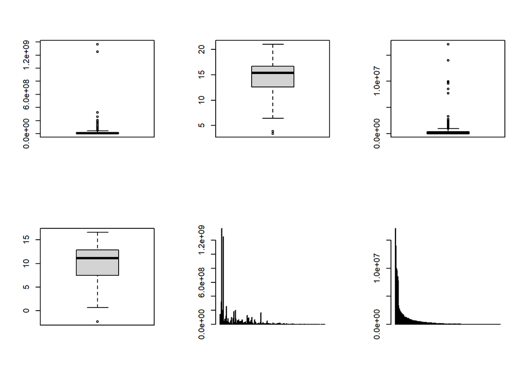

```r
par(mfrow = c(2, 3))
boxplot(d$population)
boxplot(log(d$population))
boxplot(d$area)
boxplot(log(d$area))
barplot(d$population)
barplot(d$area)
```

- Histograms: The hist() function returns a histogram showing the complete empirical distribution of the data in binned categories, which is useful for checking skewwness of the data, symmetry, multi-modality, etc. Setting the argument freq=FALSE will scale the Y axis to represent the proportion of observations falling into each bin rather than the count.
- Make histograms of the log() transformed population and area data from the Country-Data-2016 file. Explore what happens if you set freq=FALSE versus the default of freq=TRUE. Try looking at other variables as well.

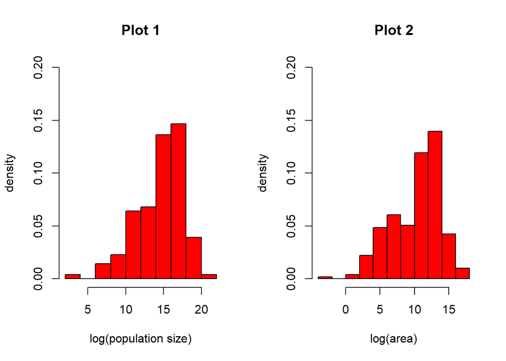

```r
par(mfrow = c(1, 2))  # gives us two panels
attach(d)
hist(log(population), freq = FALSE, col = "red", main = "Plot 1", xlab = "log(population size)",
    ylab = "density", ylim = c(0, 0.2))
hist(log(area), freq = FALSE, col = "red", main = "Plot 2", xlab = "log(area)",
    ylab = "density", ylim = c(0, 0.2))
```

```r
#NOTE: You can add a line to your histograms (e.g., to show the mean value for a variable) using the abline() command, with arguments. For exmaple, to show a single vertical line representing the mean log(population size), you would add the argument v=mean(log(population)))
```

- Density plot: The density() function computes a non-parametric estimate of the distribution of a variable, which can be combined with plot() to also yield a graphical view of the distribution of the data. If your data have missing values, then you need to add the argument na.rm=TRUE to the density() function. To superimpose a density() curve on a histogram, you can use the lines(density()) function.

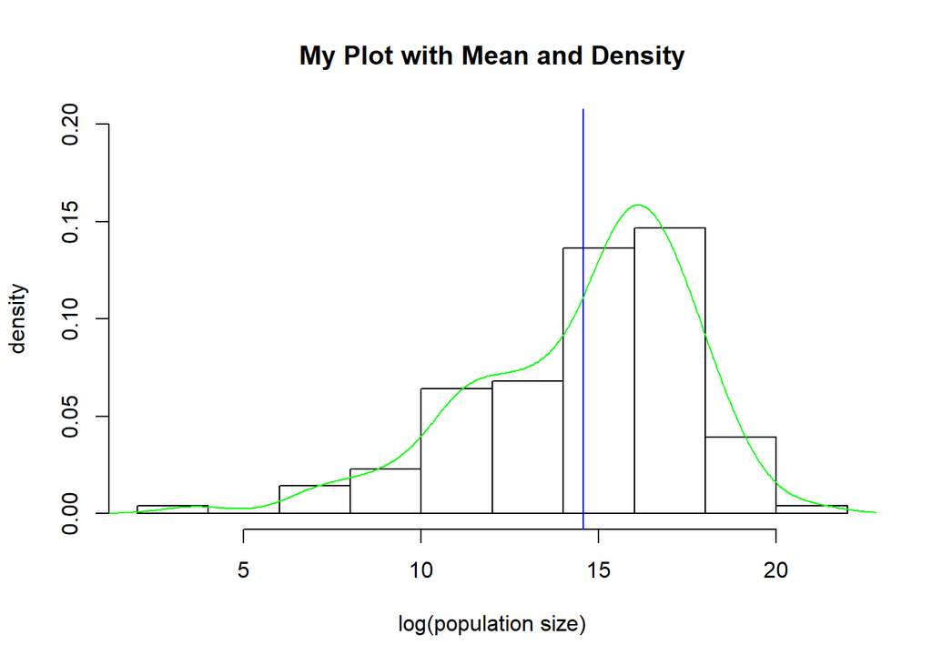

```r
par(mfrow = c(1, 1))  # set up one panel and redraw the log(population) histogram
hist(log(population), freq = FALSE, col = "white", main = "My Plot with Mean and Density",
    xlab = "log(population size)", ylab = "density", ylim = c(0, 0.2))
abline(v = mean(log(population), na.rm = TRUE), col = "blue")
lines(density(log(population), na.rm = TRUE), col = "green")
```

- Tables: the table() function can be used to summarize counts and proportions for categorical variables in your dataset.
- Using the table() function, find what is the most common form of government in the Country-Data-2016 dataset. How many countries have that form? HINT: We can combine table() with sort() and the argument decreasing=TRUE to get the desired answered straight away:

```r
sort(table(d$govt_form), decreasing = TRUE)
```

```
##
##                                republic                 constitutional monarchy
##                                     127                                      33
##              British overseas territory            overseas territory of France
##                                      12                                       7
##           presidential federal republic                                monarchy
##                                       7                                       6
##                  parliamentary monarchy          territory of the United States
##                                       5                                       5
##                 parliamentary democracy                  territory of Australia
##                                       4                                       4
## autonomous territory of the Netherlands                        federal republic
##                                       3                                       3
##                        islamic republic                      socialist republic
##                                       3                                       3
##                       absolute monarchy            autonomous region of Denmark
##                                       2                                       2
##     autonomous territory of New Zealand            overseas community of France
##                                       2                                       2
##          parliamentary federal republic  special administrative region of China
##                                       2                                       2
##                     territory of Norway                       autonomous region
##                                       2                                       1
##             autonomous region of France            autonomous region of Morocco
##                                       1                                       1
##                              federation         foreign-administrated territory
##                                       1                                       1
##      islamic-socialist peoples republic                  parliamentary republic
##                                       1                                       1
##                        peoples republic                     territory of France
##                                       1                                       1
##                territory of New Zealand            territory of the Netherlands
##                                       1                                       1
```

- For multivariate data #Multiple boxplots or histograms can be laid out side-by-side or overlaid. For boxplots, the ~ operator can be read as “by”.
- Read in the dataset KamilarAndCooperData, which contains a host of information from about 213 living primate species.
- Spend some time exploring the data and then make boxplots of log(female body mass) family. Try doing this with {base} graphics and then look at how we might do in in {ggplot2}, which provides a standard “grammar of graphics” (see the {ggplot2} documentation)

```r
f <- curl("https://raw.githubusercontent.com/fuzzyatelin/fuzzyatelin.github.io/master/AN588_Fall23/KamilarAndCooperData.csv")
d <- read.csv(f, header = TRUE, stringsAsFactors = FALSE)
attach(d)
head(d)
```

```
##               Scientific_Name          Family          Genus      Species
## 1 Allenopithecus_nigroviridis Cercopithecidae Allenopithecus nigroviridis
## 2         Allocebus_trichotis Cercopithecidae      Allocebus    trichotis
## 3           Alouatta_belzebul        Atelidae       Alouatta     belzebul
## 4             Alouatta_caraya        Atelidae       Alouatta       caraya
## 5            Alouatta_guariba        Atelidae       Alouatta      guariba
## 6           Alouatta_palliata        Atelidae       Alouatta     palliata
##   Brain_Size_Species_Mean Brain_Size_Female_Mean   Brain_size_Ref
## 1                   58.02                  53.70 Isler et al 2008
## 2                      NA                     NA
## 3                   52.84                  51.19 Isler et al 2008
## 4                   52.63                  47.80 Isler et al 2008
## 5                   51.70                  49.08 Isler et al 2008
## 6                   49.88                  48.04 Isler et al 2008
##   Body_mass_male_mean Body_mass_female_mean Mass_Dimorphism
```

[output cut: 62 more lines]

```r
summary(d)
```

```
##  Scientific_Name       Family             Genus             Species
##  Length:213         Length:213         Length:213         Length:213
##  Class :character   Class :character   Class :character   Class :character
##  Mode  :character   Mode  :character   Mode  :character   Mode  :character
##
##
##
##
##  Brain_Size_Species_Mean Brain_Size_Female_Mean Brain_size_Ref
##  Min.   :  1.63          Min.   :  1.66         Length:213
##  1st Qu.: 13.95          1st Qu.: 13.23         Class :character
##  Median : 61.45          Median : 57.20         Mode  :character
##  Mean   : 68.11          Mean   : 65.24
##  3rd Qu.: 88.48          3rd Qu.: 86.80
##  Max.   :491.27          Max.   :480.15
##  NA's   :42              NA's   :48
##  Body_mass_male_mean Body_mass_female_mean Mass_Dimorphism   Mass_Ref
##  Min.   :    31      Min.   :   30.0       Min.   :0.841   Length:213
##  1st Qu.:   865      1st Qu.:  835.5       1st Qu.:1.013   Class :character
##  Median :  4290      Median : 3039.0       Median :1.109   Mode  :character
##  Mean   :  8112      Mean   : 5396.5       Mean   :1.246
##  3rd Qu.:  7815      3rd Qu.: 6390.0       3rd Qu.:1.409
##  Max.   :170400      Max.   :97500.0       Max.   :2.688
##  NA's   :18          NA's   :18            NA's   :18
##  MeanGroupSize     AdultMales      AdultFemale     AdultSexRatio
##  Min.   : 1.00   Min.   : 0.900   Min.   : 1.000   Min.   : 0.500
##  1st Qu.: 4.00   1st Qu.: 1.000   1st Qu.: 1.000   1st Qu.: 1.000
##  Median : 7.80   Median : 1.500   Median : 2.900   Median : 1.450
##  Mean   :15.06   Mean   : 2.516   Mean   : 5.049   Mean   : 2.305
##  3rd Qu.:18.50   3rd Qu.: 3.100   3rd Qu.: 7.100   3rd Qu.: 2.770
##  Max.   :90.00   Max.   :16.000   Max.   :25.200   Max.   :15.600
##  NA's   :60      NA's   :68       NA's   :68       NA's   :84
##  Social_Organization_Ref InterbirthInterval_d   Gestation       WeaningAge_d
##  Length:213              Min.   : 144.5       Min.   : 59.99   Min.   :  40.0
##  Class :character        1st Qu.: 365.0       1st Qu.:142.00   1st Qu.: 122.4
##  Mode  :character        Median : 476.9       Median :165.04   Median : 237.7
##                          Mean   : 572.1       Mean   :163.47   Mean   : 310.0
##                          3rd Qu.: 741.4       3rd Qu.:180.75   3rd Qu.: 383.4
##                          Max.   :2007.5       Max.   :256.00   Max.   :1260.8
##                          NA's   :103          NA's   :75       NA's   :95
```

[output cut: 41 more lines]

```
##  Min.   : 9.00   Min.   : 3.00   Min.   : 4.00   Min.   : 0.900
##  1st Qu.:21.75   1st Qu.:14.93   1st Qu.:18.38   1st Qu.: 3.500
##  Median :33.30   Median :21.00   Median :30.48   Median : 5.400
##  Mean   :33.08   Mean   :21.67   Mean   :34.26   Mean   : 7.369
##  3rd Qu.:43.08   3rd Qu.:26.90   3rd Qu.:52.40   3rd Qu.:10.000
##  Max.   :63.90   Max.   :70.60   Max.   :78.50   Max.   :23.500
##  NA's   :141     NA's   :143     NA's   :143     NA's   :136
##  Activity_Budget_Ref
##  Length:213
##  Class :character
##  Mode  :character
##
##
##
##
```

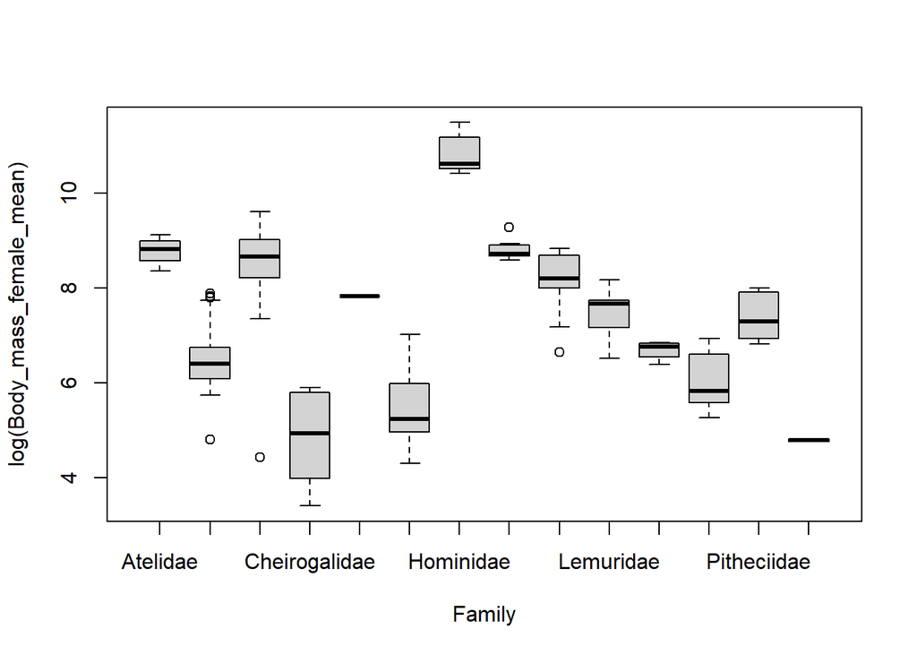

```r
boxplot(log(Body_mass_female_mean) ~ Family, d)
```

```r
detach(d)
```

- Alternatively, plotting using {ggplot2}… notice how each novel command is being added to the already-saved initial command? This is for ease of reading and understanding how we’re building the figure. All of this could also go on one line (and is read by the computer as such in the final version of the object p), but to make it easier to understand what each component it doing, we often build graphs in {ggplot2} using the below method:

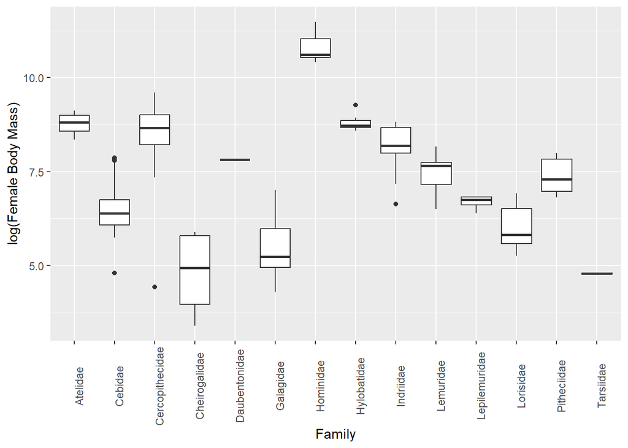

```r
library(ggplot2)
p <- ggplot(data = d, aes(x = Family, y = log(Body_mass_female_mean)))  #define the variables
p <- p + geom_boxplot()  #graph them in a boxplot
p <- p + theme(axis.text.x = element_text(angle = 90))  #put x-axis names at 90deg
p <- p + ylab("log(Female Body Mass)")  #rename y-axis title
p  #show me the graph
```

- Scatterplots: Scatterplots are a natural tool for visualizing two continuous variables and can be made easily with the plot(x=XXX, y=YYY) function in {base} graphics (where XXX* and YYY** denote the names of the two variables you wish to plot). Transformations of the variables, e.g., log or square-root (sqrt()), may be necessary for effective visualization.
- Again using data from the KamilarAndCooperData dataset, plot the relationship b between female body size and female brain size. Then, play with log transforming the data and plot again.

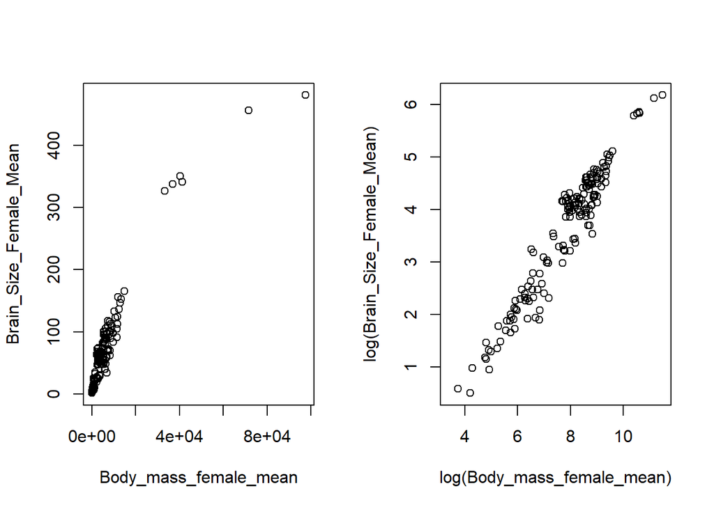

```r
attach(d)
par(mfrow = c(1, 2))
plot(x = Body_mass_female_mean, y = Brain_Size_Female_Mean)
plot(x = log(Body_mass_female_mean), y = log(Brain_Size_Female_Mean))
```

```r
detach(d)
```

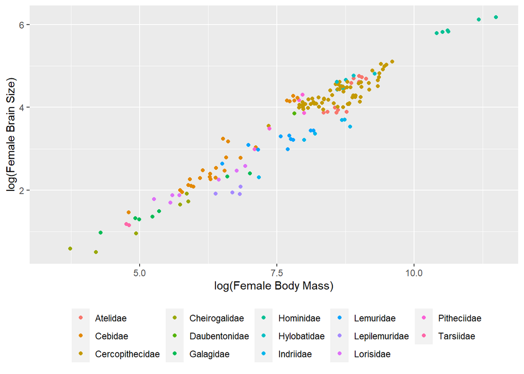

```r
#The grammar for {ggplot2} is a bit more complicated… see if you can follow it in the example below.
p <- ggplot(data = d, aes(x = log(Body_mass_female_mean), y = log(Brain_Size_Female_Mean),
    color = factor(Family)))  # first, we build a plot object and color points by Family
p <- p + xlab("log(Female Body Mass)") + ylab("log(Female Brain Size)")  # then we modify the axis labels
p <- p + geom_point()  # then we make a scatterplot
p <- p + theme(legend.position = "bottom", legend.title = element_blank())  # then we modify the legend
p  # and, finally, we plot the object
```

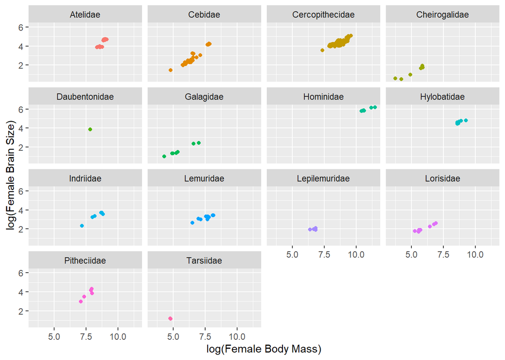

```r
#Using {ggplot2}, we can also easily set up a grid for “faceting”” by a grouping variable…
p <- p + facet_wrap(~Family, ncol = 4)
p <- p + theme(legend.position = "none")
p
```

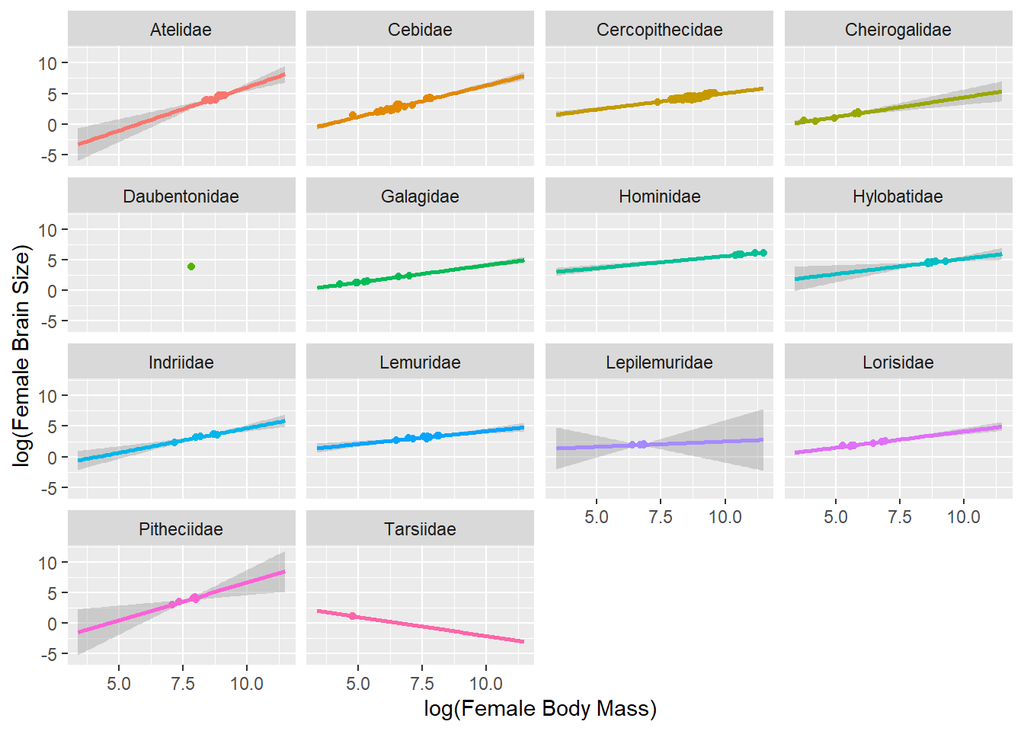

```r
#regression lines to our plot. Here, we add a linear model to each facet.
p <- p + geom_smooth(method = "lm", fullrange = TRUE)
p
```

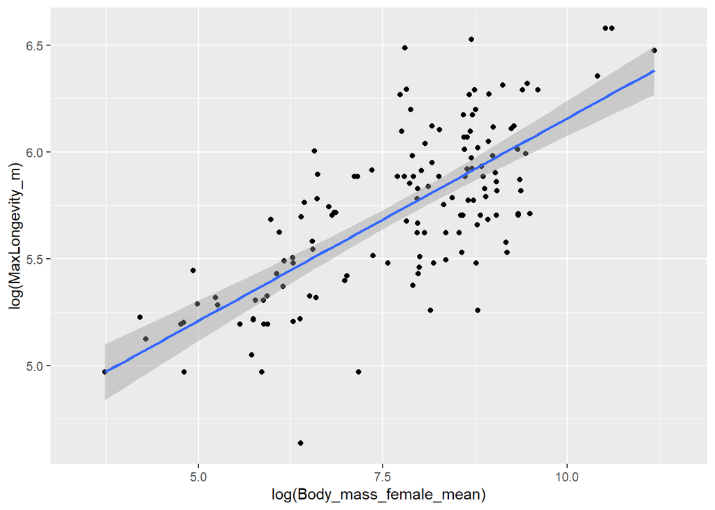

```r
#Build your own bivariate scatterplot using the KamilarAndCooperData dataset.
p <- ggplot(data = d, aes(x = log(Body_mass_female_mean), y = log(MaxLongevity_m)))
p <- p + geom_point()
p <- p + geom_smooth(method = "lm")
p
```

- Aggregate Statistics and the {dplyr} Package
- To calculate summary statistics for groups of observations in a data frame, there are many different approaches. One is to use the aggregate() function from the {stats} package (a standard package), which provides a quick way to look at summary statistics for sets of observations, though it requires a bit of clunky code. Here, we apply a particular function (FUN = “mean”) to mean female body mass, grouped by Family.

```r
aggregate(d$Body_mass_female_mean ~ d$Family, FUN = "mean", na.rm = TRUE)
```

```
##           d$Family d$Body_mass_female_mean
## 1         Atelidae               6616.2000
## 2          Cebidae                876.3323
## 3  Cercopithecidae               6327.8247
## 4    Cheirogalidae                186.0286
## 5    Daubentonidae               2490.0000
## 6        Galagidae                371.6143
## 7        Hominidae              53443.7167
## 8      Hylobatidae               6682.1200
## 9        Indriidae               3886.5333
## 10       Lemuridae               1991.1200
## 11   Lepilemuridae                813.5000
## 12       Lorisidae                489.8625
## 13     Pitheciidae               1768.5000
## 14       Tarsiidae                120.0000
```

- Or, alternatively…

```r
aggregate(x = d["Body_mass_female_mean"], by = d["Family"], FUN = "mean", na.rm = TRUE)
```

```
##             Family Body_mass_female_mean
## 1         Atelidae             6616.2000
## 2          Cebidae              876.3323
## 3  Cercopithecidae             6327.8247
## 4    Cheirogalidae              186.0286
## 5    Daubentonidae             2490.0000
## 6        Galagidae              371.6143
## 7        Hominidae            53443.7167
## 8      Hylobatidae             6682.1200
## 9        Indriidae             3886.5333
## 10       Lemuridae             1991.1200
## 11   Lepilemuridae              813.5000
## 12       Lorisidae              489.8625
## 13     Pitheciidae             1768.5000
## 14       Tarsiidae              120.0000
```

- Another, EASIER, way to summarize data is to use the package {dplyr}, which provides “a flexible grammar of data manipulation” that includes a set of verbs that can be used to perform useful operations on data frames. Before using {dplyr} for this, let’s look in general at what it can do…

```r
library(dplyr)
s <- filter(d, Family == "Hominidae" & Mass_Dimorphism > 2)
head(s)  # filtering a data frame for certain rows...
```

```
##   Scientific_Name    Family   Genus  Species Brain_Size_Species_Mean
## 1 Gorilla_gorilla Hominidae Gorilla  gorilla                  490.41
## 2    Pongo_abelii Hominidae   Pongo   abelii                  389.50
## 3  Pongo_pygmaeus Hominidae   Pongo pygmaeus                  377.38
##   Brain_Size_Female_Mean   Brain_size_Ref Body_mass_male_mean
## 1                 455.89 Isler et al 2008            170400.0
## 2                 341.21 Isler et al 2008             84482.5
## 3                 337.72 Isler et al 2008             80136.9
##   Body_mass_female_mean Mass_Dimorphism         Mass_Ref MeanGroupSize
## 1               71500.0           2.383 Isler et al 2008           7.1
## 2               41148.0           2.053 Isler et al 2008            NA
## 3               36947.6           2.169 Isler et al 2008           2.0
##   AdultMales AdultFemale AdultSexRatio
## 1        1.8         4.4          2.44
## 2         NA          NA            NA
```

[output cut: 29 more lines]

```r
s <- arrange(d, Family, Genus, Body_mass_male_mean)  # rearranging a data frame...
head(s)
```

```
##      Scientific_Name   Family    Genus   Species Brain_Size_Species_Mean
## 1   Alouatta_guariba Atelidae Alouatta   guariba                   51.70
## 2    Alouatta_caraya Atelidae Alouatta    caraya                   52.63
## 3 Alouatta_seniculus Atelidae Alouatta seniculus                   55.22
## 4  Alouatta_palliata Atelidae Alouatta  palliata                   49.88
## 5  Alouatta_belzebul Atelidae Alouatta  belzebul                   52.84
## 6     Alouatta_pigra Atelidae Alouatta     pigra                   51.13
##   Brain_Size_Female_Mean   Brain_size_Ref Body_mass_male_mean
## 1                  49.08 Isler et al 2008                5800
## 2                  47.80 Isler et al 2008                6525
## 3                  54.26 Isler et al 2008                6690
## 4                  48.04 Isler et al 2008                7150
## 5                  51.19 Isler et al 2008                7270
## 6                  48.75 Isler et al 2008               11400
##   Body_mass_female_mean Mass_Dimorphism         Mass_Ref MeanGroupSize
```

[output cut: 62 more lines]

```r
s <- select(d, Family, Genus, Body_mass_male_mean)  # selecting specific columns...
head(s)
```

```
##            Family          Genus Body_mass_male_mean
## 1 Cercopithecidae Allenopithecus                6130
## 2 Cercopithecidae      Allocebus                  92
## 3        Atelidae       Alouatta                7270
## 4        Atelidae       Alouatta                6525
## 5        Atelidae       Alouatta                5800
## 6        Atelidae       Alouatta                7150
```

```r
s <- rename(d, Female_Mass = Body_mass_female_mean)
head(s$Female_Mass)  # renaming columns...
```

```
## [1] 3180   84 5520 4240 4550 5350
```

```r
s <- mutate(d, Binomial = paste(Genus, Species, sep = " "))
head(s$Binomial)  # and adding new columns...
```

```
## [1] "Allenopithecus nigroviridis" "Allocebus trichotis"
## [3] "Alouatta belzebul"           "Alouatta caraya"
## [5] "Alouatta guariba"            "Alouatta palliata"
```

- The {dplyr} package also makes it easy to summarize data using more convenient functions than aggregate(). For example:

```r
s <- summarise(d, avgF = mean(Body_mass_female_mean, na.rm = TRUE), avgM = mean(Body_mass_male_mean,
    na.rm = TRUE))
s
```

```
##       avgF     avgM
## 1 5396.474 8111.801
```

- The group_by() function allows us to do apply summary functions to sets of observations defined by a categorical variable, as we did above with aggregate().

```r
byFamily <- group_by(d, Family)
byFamily
```

```
## # A tibble: 213 × 44
## # Groups:   Family [14]
##    Scientific_Name             Family       Genus Species Brain_Size_Species_M…¹
##    <chr>                       <chr>        <chr> <chr>                    <dbl>
##  1 Allenopithecus_nigroviridis Cercopithec… Alle… nigrov…                   58.0
##  2 Allocebus_trichotis         Cercopithec… Allo… tricho…                   NA
##  3 Alouatta_belzebul           Atelidae     Alou… belzeb…                   52.8
##  4 Alouatta_caraya             Atelidae     Alou… caraya                    52.6
##  5 Alouatta_guariba            Atelidae     Alou… guariba                   51.7
##  6 Alouatta_palliata           Atelidae     Alou… pallia…                   49.9
##  7 Alouatta_pigra              Atelidae     Alou… pigra                     51.1
##  8 Alouatta_seniculus          Atelidae     Alou… senicu…                   55.2
##  9 Aotus_azarai                Cebidae      Aotus azarai                    20.7
## 10 Aotus_brumbacki             Cebidae      Aotus brumba…                   NA
## # ℹ 203 more rows
## # ℹ abbreviated name: ¹Brain_Size_Species_Mean
## # ℹ 39 more variables: Brain_Size_Female_Mean <dbl>, Brain_size_Ref <chr>,
## #   Body_mass_male_mean <dbl>, Body_mass_female_mean <dbl>,
## #   Mass_Dimorphism <dbl>, Mass_Ref <chr>, MeanGroupSize <dbl>,
## #   AdultMales <dbl>, AdultFemale <dbl>, AdultSexRatio <dbl>,
## #   Social_Organization_Ref <chr>, InterbirthInterval_d <dbl>, …
```

```r
s <- summarise(byFamily, avgF = mean(Body_mass_female_mean, na.rm = TRUE), avgM = mean(Body_mass_male_mean,
    na.rm = TRUE))
s
```

```
## # A tibble: 14 × 3
##    Family            avgF   avgM
##    <chr>            <dbl>  <dbl>
##  1 Atelidae         6616.  7895.
##  2 Cebidae           876.  1012.
##  3 Cercopithecidae  6328.  9543.
##  4 Cheirogalidae     186.   193.
##  5 Daubentonidae    2490   2620
##  6 Galagidae         372.   395.
##  7 Hominidae       53444. 98681.
##  8 Hylobatidae      6682.  6926.
##  9 Indriidae        3887.  3638.
## 10 Lemuridae        1991.  2077.
## 11 Lepilemuridae     814.   792
## 12 Lorisidae         490.   512.
## 13 Pitheciidae      1768.  1955.
## 14 Tarsiidae         120    131
```

- Piping
- One other cool thing about the {dplyr} package is that it provides a convenient way to “pipe” together operations on a data frame using the %>% operator. This means that each line of code after the operator is implemented on the product of the line of code before the operator.In this way, you can use piping to build, step by step, a more complicated output.
- As an example, the line of code, below, accomplishes the same as the multiple line of code in the previous chunk (although it is only one line of code, I’ve separated it by pipes for ease of reading and understanding (see hashes for a descriptor of what each pipe section accomplishes)… it could also be written as one continuous line):
- Piping allows us to keep a clean and readable workflow without having to create numerous intermediate dataframes, as well as offering us a shorthand that accomplishes one complicated process with one simple-to-breakdown command.
- Although this may at first seem cumbersome (many students despise piping at first!), it will quickly become one of the best ways to make your code more readable and simpler to implement.

```r
s <-
  d %>%
  group_by(Family) %>%
  summarise(avgF = mean(Body_mass_female_mean, na.rm=TRUE),
            avgM = mean(Body_mass_male_mean, na.rm=TRUE))
s
```

```
## # A tibble: 14 × 3
##    Family            avgF   avgM
##    <chr>            <dbl>  <dbl>
##  1 Atelidae         6616.  7895.
##  2 Cebidae           876.  1012.
##  3 Cercopithecidae  6328.  9543.
##  4 Cheirogalidae     186.   193.
##  5 Daubentonidae    2490   2620
##  6 Galagidae         372.   395.
##  7 Hominidae       53444. 98681.
##  8 Hylobatidae      6682.  6926.
##  9 Indriidae        3887.  3638.
## 10 Lemuridae        1991.  2077.
## 11 Lepilemuridae     814.   792
## 12 Lorisidae         490.   512.
## 13 Pitheciidae      1768.  1955.
## 14 Tarsiidae         120    131
```

- In one line of code, do the following:
- Add a variable, Binomial to our data frame d, which is a concatenation of the Genus and Species…
- Trim the data frame to only include the variables Binomial, Family, Body_mass_female_mean, Body_mass_male_mean and Mass_Dimorphism…
- Group these by Binomial (in other words, by species but with full binomial nomenclature)…
- And calculate the average value for female body mass, male body mass, and mass dimorphism.

```r
s <- d %>%
    mutate(Binomial = paste(Genus, Species, sep = " ")) %>%
    select(Binomial, Body_mass_female_mean, Body_mass_male_mean, Mass_Dimorphism) %>%
    group_by(Binomial) %>%
    summarise(avgF = mean(Body_mass_female_mean, na.rm = TRUE), avgM = mean(Body_mass_male_mean,
        na.rm = TRUE), avgBMD = mean(Mass_Dimorphism, na.rm = TRUE))
s
```

```
## # A tibble: 213 × 4
##    Binomial                     avgF  avgM  avgBMD
##    <chr>                       <dbl> <dbl>   <dbl>
##  1 Allenopithecus nigroviridis  3180  6130   1.93
##  2 Allocebus trichotis            84    92   1.10
##  3 Alouatta belzebul            5520  7270   1.32
##  4 Alouatta caraya              4240  6525   1.54
##  5 Alouatta guariba             4550  5800   1.27
##  6 Alouatta palliata            5350  7150   1.34
##  7 Alouatta pigra               6430 11400   1.77
##  8 Alouatta seniculus           5210  6690   1.28
##  9 Aotus azarai                 1230  1180   0.959
## 10 Aotus brumbacki               NaN   NaN NaN
## # ℹ 203 more rows
```

- According to Kamilar & Cooper’s (2013) dataset, what is the average male and female size, and body mass dimorphism of my two main study species (vervet monkeys, Chlorocebus pygerythrus; and woolly monkeys, Lagothrix lagotricha)? Which has a larger average female body mass? Which is more sexually dimorphic?

```r
library (dplyr)
s %>% filter(Binomial == "Chlorocebus pygerythrus" | Binomial == "Lagothrix lagotricha")
```

```
## # A tibble: 2 × 4
##   Binomial                 avgF  avgM avgBMD
##   <chr>                   <dbl> <dbl>  <dbl>
## 1 Chlorocebus pygerythrus 3576. 5071.   1.42
## 2 Lagothrix lagotricha    7020  7280    1.04
```

- Compare the body size of my two main study taxa at the Family level (i.e., Cercopithecidae vs. Atelidae) by plotting (using {ggplot2}) the body mass of males and females and sexual dimorphism. If you can, make the Cercopithecid boxes green, and the Atelid boxes purple.

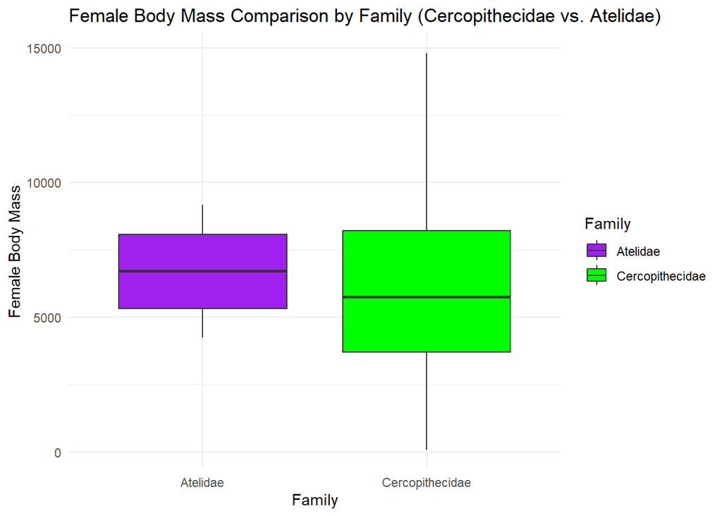

```r
library(ggplot2)

# Filter the data for the two study families and females
filtered_data <- d %>%
  filter(Family %in% c("Cercopithecidae", "Atelidae"))

# Create a boxplot for female body mass
boxplot_plot <- ggplot(filtered_data, aes(x = Family, y = Body_mass_female_mean, fill = Family)) +
  geom_boxplot() +
  labs(title = "Female Body Mass Comparison by Family (Cercopithecidae vs. Atelidae)",
       x = "Family",
       y = "Female Body Mass") +
  scale_fill_manual(values = c("Cercopithecidae" = "green", "Atelidae" = "purple")) +
  theme_minimal()

# Print the plot
print(boxplot_plot)
```

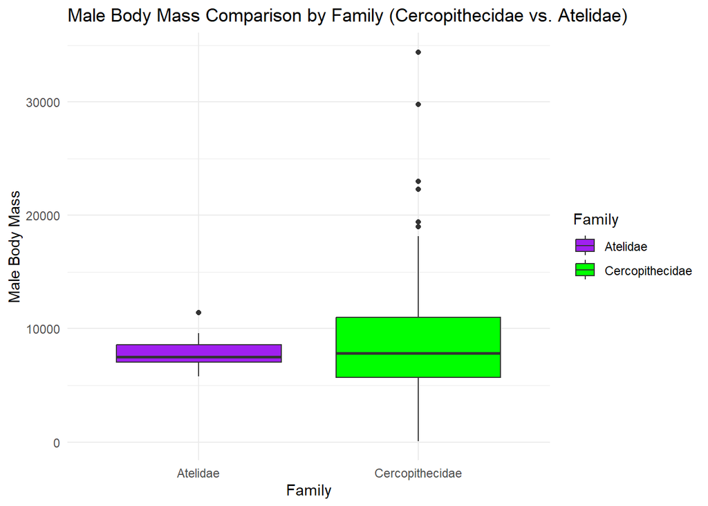

```r
library(ggplot2)

# Filter the data for the two study families and females
filtered_data <- d %>%
  filter(Family %in% c("Cercopithecidae", "Atelidae"))

# Create a boxplot for female body mass
boxplot_plot <- ggplot(filtered_data, aes(x = Family, y = Body_mass_male_mean, fill = Family)) +
  geom_boxplot() +
  labs(title = "Male Body Mass Comparison by Family (Cercopithecidae vs. Atelidae)",
       x = "Family",
       y = "Male Body Mass") +
  scale_fill_manual(values = c("Cercopithecidae" = "green", "Atelidae" = "purple")) +
  theme_minimal()

# Print the plot
print(boxplot_plot)
```

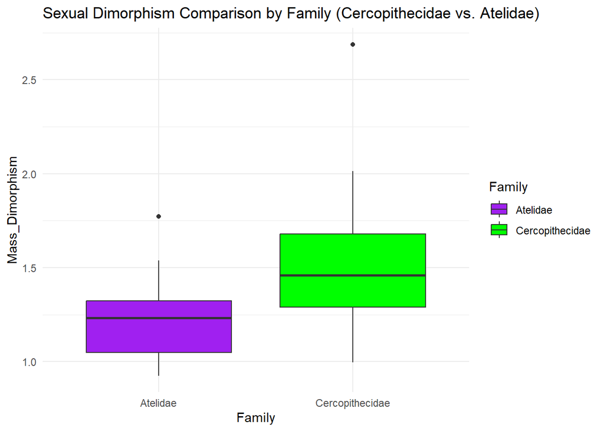

```r
library(ggplot2)

# Filter the data for the two study families and females
filtered_data <- d %>%
  filter(Family %in% c("Cercopithecidae", "Atelidae"))

# Create a boxplot for Sexual Dimorphism
boxplot_plot <- ggplot(filtered_data, aes(x = Family, y = Mass_Dimorphism, fill = Family)) +
  geom_boxplot() +
  labs(title = "Sexual Dimorphism Comparison by Family (Cercopithecidae vs. Atelidae)",
       x = "Family",
       y = "Mass_Dimorphism") +
  scale_fill_manual(values = c("Cercopithecidae" = "green", "Atelidae" = "purple")) +
  theme_minimal()

# Print the plot
print(boxplot_plot)
```

(Module 7: Central Tendency and Variance)

```r
x <- c(1, 2, 3, 4, 5, 6, 7, 8, 9, 10, 25, 50, 100, 200, 1000)
gm1 <- function(x) {
    prod(x)^(1/length(x))
}
gm1(x)
```

```
## [1] 13.50559
```

```r
gm2 <- function(x) {
    exp(mean(log(x)))
}
gm2(x)
```

```
## [1] 13.50559
```

- Measures of Spread
- A measure of spread or variability in a dataset is one of the most important summary statistics to calculate. The range (min to max) is one measure of spread as is the interquartile range (25th to 75th quartile). As we’ve seen, these are returned by the summary() function.
- We commonly characterize spread, however, in terms of the deviation of values from the mean. One such measure is the sum of squares…
- sum of squares = the sum of the squared deviations of a set of values from the mean
- [Why do we use the sum of the squared deviations of values from the mean rather than just the sum of deviations? Because the latter would simply be ZERO.]

```r
ss1 <- function(x) {
    sum((x - mean(x))^2)
}
ss1(x)
```

```
## [1] 917183.3
```

- This is equivalent to…

```r
ss2 <- function(x) {
    sum(x^2) - length(x) * mean(x)^2
}
ss2(x)
```

```
## [1] 917183.3
```

- A shortcut to calculate the sum of squares that does not require calculating mean(x) is the (sum of the squared values in the dataset) minus the (square of the summed values / n). Thus, another formula for the sum of squares is:

```r
ss3 <- function(x) {
    sum(x^2) - (sum(x))^2/length(x)
}
ss3(x)
```

```
## [1] 917183.3
```

- The sum of squares increases with sample size… you can see this by adding more data points to your vector. To be able to compare across data sets, we are then more interested in the average deviation of values from the mean rather than the straight sum of squares, i.e., a mean squared deviation. This is the definition of the variability or variance in a dataset. If we are simply interested in describing the mean squared deviation in a population, where we have a value or measurement for every case (e.g., the femur length of all of the vervet monkeys in a musuem population), we could then just divide the sum of squares by the number of cases.
- population variance = sum of squares / N
- In R parlance, we can write:

```r
pop_v <- function(x) {
    sum((x - mean(x))^2)/(length(x))
}
pop_v(x)
```

```
## [1] 61145.56
```

- If, however, we have not measured all of the individual cases in population… if we are, instead, dealing with a sample from the population and are trying to use that sample to say something about the population from which it is drawn (e.g., to say something about vervet monkey femur lengths in general based on those that appear in a museum sample) then we need to use a slightly different formula to get an unbiased estimate of the population variance. Such an estimate for a population parameter, based on data from a sample, is calculated as:
- sample variance = estimator of the population variance = sum of squares / (n - 1)
- In this formula, n - 1 is the number of degrees of freedom implied by the sample. The degrees of freedom is the number of values used to calculate a sample statistic that are free to vary. We used n observations to calculate the mean of our sample, and that implies n - 1 degrees of freedom. We use that statistic about our sample as an estimate of the population mean, which is used to derive an estimate of the population variance.
- Write a function to calculate the variance for a vector of values representing a sample of measurements. Compare the results of your function to the built-in function, var(), which calculates sample variance.

```r
sample_v <- function(x) {
    sum((x - mean(x))^2)/(length(x) - 1)
}
sample_v(x)
```

```
## [1] 65513.1
```

- Interesting Questions to Ask: How does Sample Variance compare to Population Variance? What happens to the sample variance as sample size increases?
- For a random variable, how is variance related to sample size? Let’s explore this…

[figure not shown]

```r
#[1] Set up a PLOT:
plot(c(0, 50), c(0, 15), type = "n", xlab = "Sample size", ylab = "Variance")
```

- Another measure of spread around a mean that we often see reported is the standard deviation. The standard deviation is simply the square root of the variance. The advantage of using the standard deviation as a statistic or parameter is that the units of standard deviation are the same as those of our original measurement (rather than being units squared, our units for variance).
- In R we can write…

```r
pop_sd <- function(x) {
    sqrt(pop_v(x))
}
pop_sd(x)
```

```
## [1] 247.2763
```

- Using Measures of Spread
- Describing Uncertainty in Estimated Parameters
- We would also like to have an idea, based on characteristics of our sample, how reliable or unreliable our estimates of population parameters based on those samples are. In general, we would expect such a measure of uncertainty, or error, to increase with the variability in our sample (estimates with high variability are more uncertain) and to decrease as we sample more. That is, it should be proportional to the ratio of variance to sample size.
- Also, ideally, the units for our estimate of error should be the same as those of our original measurements. Since the ratio above would be expressed in square units (since sample size is dimensionless), we can take the square root to express it in units.
- The standard error of the mean, based on a sample, can thus be defined as follows:
- SE mean = square root of the average sample variance

or

- SE mean = square root of (sample variance / number of observations)

or

- SE mean = (sample standard deviation) / square root of (number of observation

```r
sample_sd <- function(x) {
    sqrt(sample_v(x))
}
sample_sd(x)
```

```
## [1] 255.9553
```

- Write a function to calculate the standard error of the mean for a vector of values representing a sample of measurements. You can use either your own function for sample variance or the built-in var() function

```r
SE1 <- function(x) {
    sqrt(sample_v(x)/length(x))
}
SE1(x)
```

```
## [1] 66.08736
```

```r
SE2 <- function(x) {
    sqrt(var(x)/length(x))
}
SE2(x)
```

```
## [1] 66.08736
```

```r
#The package {sciplot} also includes the function, se(), for calculating standard errors (as do others).
library(sciplot)
se(x)
```

```
## [1] 66.08736
```

- Calculating Confidence Intervals using Standard Errors
- Standard errors can be used to calculate the confidence intervals around an estimate. A confidence interval shows the likely range of values into which an estimate would fall if the sampling exercise were to be repeated. We can talk about different confidence intervals (e.g., 50%, 95%, 99%), and the higher the confidence we want to have, the wider the interval will be.
- The 95% confidence interval, then, describes the range of values into which a statistic, calculated based on a repeated sample, would be expected to fall 95% of the time. We typically estimate confidence intervals with respect to specific theoretical distributions (e.g., normal, Poisson, Student’s t, F) and different characteristics about our sample (e.g., mean, standard deviation, degrees of freedom).
- For example, suppose we wanted to calculate a 95% confidence interval around our estimate of the mean for a particular set of observations, assuming those data reflect a random variable that is normally distributed and that our observations are independent. We would simply find the values corresponding to the numbers of standard errors away from the mean our statistic would be expected to fall 95% of the time.
- We can calculate this by multiplying our estimate of the standard error by the quantile normal (qnorm()) function. Basically, we give the qnorm() function a quantile, and it returns the value of X below which that proportion of the cumulative probability function falls. For example, qnorm(0.025, mean=0, sd=1) tells us the number of standard deviations away from the mean that correspond with up to 2.5% of of the normal distribution with mean=0 and sd=1. qnorm(0.975, mean=0, sd=1) tells us the number of standard deviations up to which 97.5% of observations should fall.
- Let’s take a quick look at the NORMAL DISTRIBUTION. Here, we use the rnorm() function to sample 10000 numbers from a normal distribution with mean = 0 and standard deviation = 1. [I am using set.seed() here so that each time I run this function, I return the same set of random numbers.]

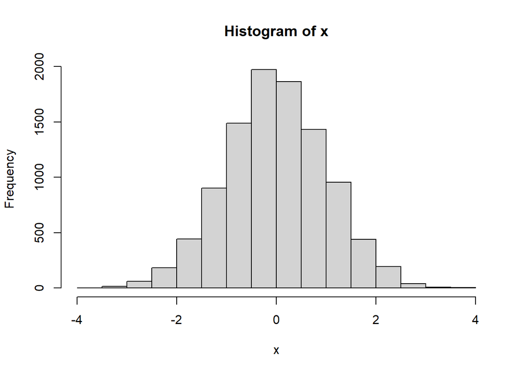

```r
set.seed(1)
x <- rnorm(10000, 0, 1)
hist(x)
```

- Now try this… plot the density and probability distributions for a normal distribution. In these plots, cex= sets the size of the points being plotted.

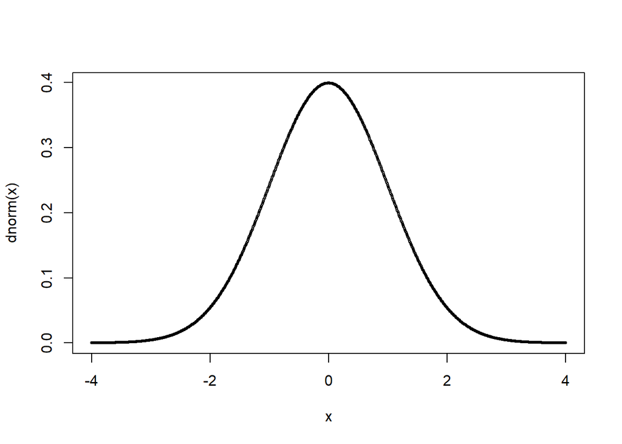

```r
x <- seq(from = -4, to = 4, by = 0.01)
plot(x, dnorm(x), cex = 0.4)
```

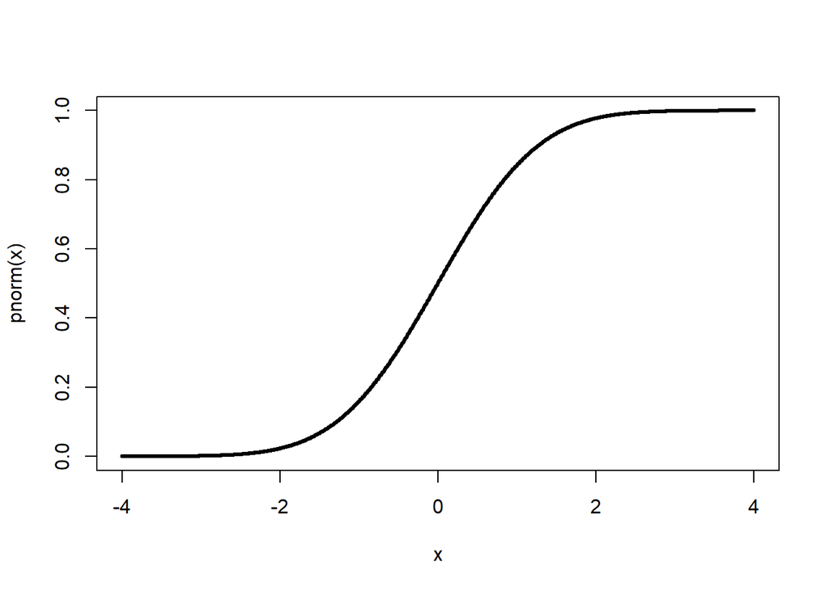

```r
plot(x, pnorm(x), cex = 0.4)
```

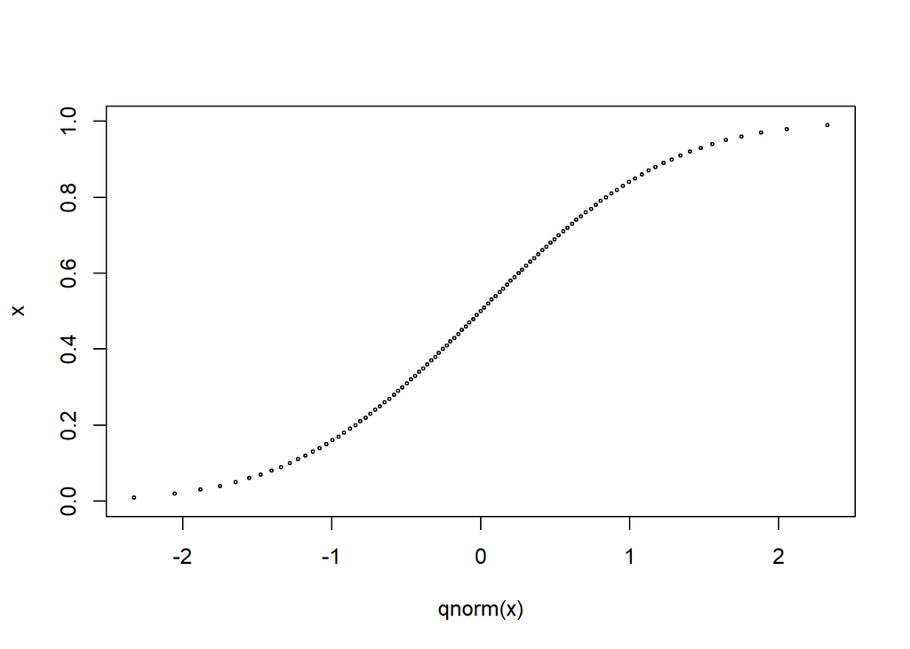

```r
x <- seq(from = 0, to = 1, by = 0.01)
plot(qnorm(x), x, cex = 0.4)
```

```r
#Returning to calculating CIs, suppose we have this vector:
x <- c(1, 2, 3, 4, 5, 6, 7, 8, 9, 10, 11, 12, 13, 14, 15)
m <- mean(x)
n <- length(x)
v <- var(x)
s <- sd(x)
e <- sqrt(v/n)
upper <- mean(x) + qnorm(0.975, mean = 0, sd = 1) * se(x)
lower <- mean(x) + qnorm(0.025, mean = 0, sd = 1) * se(x)  # or lower <- mean(x) - qnorm(0.975)*se(x)
ci <- c(lower, upper)
ci
```

```
## [1]  5.736829 10.263171
```

- Or, alternatively…

```r
upper <- m + qnorm(0.975, mean = 0, sd = 1) * e
lower <- m + qnorm(0.025, mean = 0, sd = 1) * e  # or lower <- m - qnorm(0.975)*e
ci <- c(lower, upper)
ci
```

```
## [1]  5.736829 10.263171
```

- Alternatively, we can define our own generic CI function based on the normal distribution:

```r
normalCI = function(x, CIlevel = 0.95) {
    upper = m + qnorm(1 - (1 - CIlevel)/2) * sqrt(var(x)/length(x))
    lower = m + qnorm((1 - CIlevel)/2) * sqrt(var(x)/length(x))
    ci <- c(lower, upper)
    return(ci)
}
normalCI(x, 0.95)  # call the function
```

```
## [1]  5.736829 10.263171
```

- Interpretation of CIs:
- Based on the given data (with a particular mean, variance, and sample size) we are 95% confident that the true mean of the population is between these bounds. #A repeated sample from the same distribution is expected to fall into this interval 95% of the time.
- Calculating Confidence Intervals by Bootstrapping #An alternative way to calculate a confidence interval is by simulation, which does not presume the underlying distribution from which the random variable is drawn. Here, we use the sample() function to sample, with replacement, 15 numbers from our vector x a total of 10000 times.

```r
set <- NULL  # sets up a dummy variable to hold our 10000 simulations
n <- 15
for (i in 1:10000) {
    set[i] <- mean(sample(x, n, replace = TRUE))
}
#The quantile() function returns, for your set of data, the observations satisfying the nth quantile.
quantile(set)
```

```
##        0%       25%       50%       75%      100%
##  3.200000  7.200000  8.000000  8.733333 12.200000
```

```r
quantile(set, c(0.025, 0.975))
```

```
##     2.5%    97.5%
##  5.80000 10.13333
```

{R Challenge 5}

- How does the CI calculated this way, by simulation, compare to that calculated based on assuming a normal distribution?
- Simulation- Based CI:does not presume the underlying distribution from which the random variable is drawn. Instead, it uses resampling methods like bootstrapping simulations to estimate the distribution of a statistic (e.g., mean, median, percentiles) directly from the data.
- Normal Distribution- Based CI: assumes that the data follows a normal distribution. They are computationally simpler to calculate compared to simulation-based methods, as they often involve straightforward formulas.
- How does the width of the CI change with decreasing or increasing n (the number of observations drawn from your sample with replacement)? For example, if we set n at 5? At 50? At 500?
- The width of a confidence interval (CI) generally changes with the number of observations (n) in your sample, regardless of whether you are using simulation-based methods like bootstrapping or assuming a normal distribution.
- Smaller Sample Size (n=5):
- With a small sample size, the CI tends to be wider. This is because smaller samples have higher sampling variability, which results in less precision in estimating population parameters.
- Moderate Sample Size (n=50):
- As the sample size increases, the CI becomes narrower. Larger samples provide more information about the population, reducing the uncertainty in the estimate. The narrowing of the CI is a result of improved precision in estimating the population parameter.
- Large Sample Size (n=500):
- With a very large sample size, the CI becomes even narrower. The increased narrowing of the CI is a result of very high accuracy in estimating the population parameter.
- Key Takeaway: Increasing the number of observations drawn from your sample decreases the width of confidence intervals, because it decreases the standard error.

[output not shown]